# Codebook example with Qualtrics dataset

Ruben Arslan

2018-08-01

```r
knit_by_pkgdown <- !is.null(knitr::opts_chunk$get("fig.retina"))
knitr::opts_chunk$set(warning = FALSE, message = FALSE, error = TRUE, echo = TRUE)
pander::panderOptions("table.split.table", Inf)
ggplot2::theme_set(ggplot2::theme_bw())
library(codebook)
library(dplyr)
```

Here, I try to demonstrate that we can also use the metadata generated by Qualtrics. Because I am not a Qualtrics user, the developer of the `qualtRics` R package sent me two example files, one of data and one for metadata, which I use here. Usually, you’d import these files directly via his package.

## Load

```r
# library(qualtRics) # currently not on CRAN, so commented out
results <- readRDS(system.file("extdata", "ryan.rds", package = "codebook"))
metadata_ex <- readRDS(system.file("extdata", "metadata.rds", package = "codebook"))
```

Now, we want the metadata not to be just independet of the data frame. It’s easier to change metadata if it is in the form of a list at the dataset level, so let’s use `rio::gather_attrs` for that.

```r
results <- results %>% rio::gather_attrs()
attributes(results)$label$Q7
```

```
##                                                                                  Q7
## "How reasonable or unreasonable is the cost of courses/tuition at this university?"
```

Now, we can loop over the metadata list and put it in the right shape to become attributes. This means given each element the name of the variable it refers to.

```r
names(metadata_ex$questions) <- lapply(metadata_ex$questions, function(x) {
  x$questionName
})
```

We only want the questions that we have data for.

```r
qs <- names(metadata_ex$questions)
qs <- qs[qs %in% names(attributes(results)$label)]
```

Now, we assign our metadata list to the attributes of the data.frame.

```r
init <- vector("list", ncol(results))
names(init) <- names(results)
attributes(results)$item <- init
attributes(results)$item[qs] <- metadata_ex$questions[qs]
```

And use rio to put the attributes on the question level again.

```r
results <- results %>% rio::spread_attrs()
```

To keep this example, we select a subset of variables.

```r
results <- results %>% select(ResponseSet, Q7, Q10)
if (!knit_by_pkgdown) knitr::opts_chunk$set(echo = FALSE)
```

Please note, that we just reuse the metadata column names from Qualtrics. Standardising this across multiple survey providers would be great but requires more knowledge of Qualtrics than I have.

Owing to a bug in pander, the deeply nested attribute structure is currently not shown as a nice list.

## Items

### ResponseSet

ResponseSet

#### Distribution

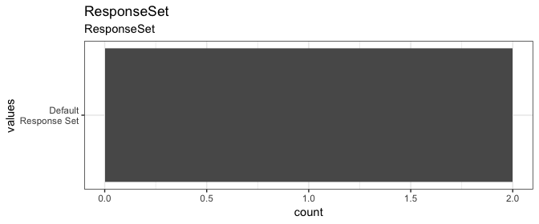

0 missings.

#### Summary statistics

| name | data_type | missing | complete | n | empty | n_unique | min | max | ResponseSet |
| --- | --- | --- | --- | --- | --- | --- | --- | --- | --- |
| ResponseSet | character | 0 | 2 | 2 | 0 | 1 | 20 | 20 | ResponseSet |

### Q7

How reasonable or unreasonable is the cost of courses/tuition at this university?

#### Distribution

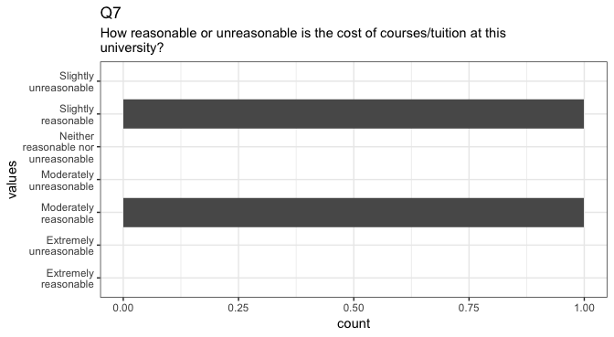

0 missings.

#### Summary statistics

| name | type | data_type | ordered | value_labels | missing | complete | n | n_unique | top_counts | Q7 | selector | subSelector | questionText | doesForceResponse | questionName |
| --- | --- | --- | --- | --- | --- | --- | --- | --- | --- | --- | --- | --- | --- | --- | --- |
| Q7 | MC | factor | TRUE | 1. Extremely reasonable, 2. Moderately reasonable, 3. Slightly reasonable, 4. Neither reasonable nor unreasonable, 5. Slightly unreasonable, 6. Moderately unreasonable, 7. Extremely unreasonable | 0 | 2 | 2 | 2 | Mod: 1, Sli: 1, Ext: 0, Nei: 0 | How reasonable or unreasonable is the cost of courses/tuition at this university? | SAVR | TX | How reasonable or unreasonable is the cost of courses/tuition at this university? | FALSE | Q7 |

#### Item

- **questionType**:
  - **type**: MC
  - **selector**: SAVR
  - **subSelector**: TX
- **questionText**: How reasonable or unreasonable is the cost of courses/tuition at this university?
- **questionLabel**:
- **validation**:
  - **doesForceResponse**: *FALSE*
- **questionName**: Q7
- **choices**:
  - **1**:

    ```
      * **recode**: 1
      * **description**: Extremely reasonable
      * **choiceText**: Extremely reasonable
      * **imageDescription**:
      * **variableName**:
      * **analyze**: _TRUE_
    ```

  - **2**:

    ```
      * **recode**: 2
      * **description**: Moderately reasonable
      * **choiceText**: Moderately reasonable
      * **imageDescription**:
      * **variableName**:
      * **analyze**: _TRUE_
    ```

  - **3**:

    ```
      * **recode**: 3
      * **description**: Slightly reasonable
      * **choiceText**: Slightly reasonable
      * **imageDescription**:
      * **variableName**:
      * **analyze**: _TRUE_
    ```

  - **4**:

    ```
      * **recode**: 4
      * **description**: Neither reasonable nor unreasonable
      * **choiceText**: Neither reasonable nor unreasonable
      * **imageDescription**:
      * **variableName**:
      * **analyze**: _TRUE_
    ```

  - **5**:

    ```
      * **recode**: 5
      * **description**: Slightly unreasonable
      * **choiceText**: Slightly unreasonable
      * **imageDescription**:
      * **variableName**:
      * **analyze**: _TRUE_
    ```

  - **6**:

    ```
      * **recode**: 6
      * **description**: Moderately unreasonable
      * **choiceText**: Moderately unreasonable
      * **imageDescription**:
      * **variableName**:
      * **analyze**: _TRUE_
    ```

  - **7**:

    ```
      * **recode**: 7
      * **description**: Extremely unreasonable
      * **choiceText**: Extremely unreasonable
      * **imageDescription**:
      * **variableName**:
      * **analyze**: _TRUE_
    ```

### Q10

How helpful or unhelpful is the staff at the on-campus health center?

#### Distribution

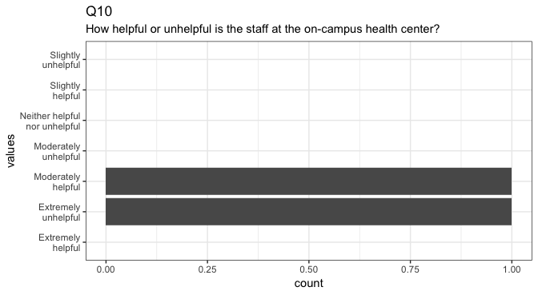

0 missings.

#### Summary statistics

| name | type | data_type | ordered | value_labels | missing | complete | n | n_unique | top_counts | Q10 | selector | subSelector | questionText | doesForceResponse | questionName |
| --- | --- | --- | --- | --- | --- | --- | --- | --- | --- | --- | --- | --- | --- | --- | --- |
| Q10 | MC | factor | TRUE | 1. Extremely helpful, 2. Moderately helpful, 3. Slightly helpful, 4. Neither helpful nor unhelpful, 5. Slightly unhelpful, 6. Moderately unhelpful, 7. Extremely unhelpful | 0 | 2 | 2 | 2 | Mod: 1, Ext: 1, Ext: 0, Sli: 0 | How helpful or unhelpful is the staff at the on-campus health center? | SAVR | TX | How helpful or unhelpful is the staff at the on-campus health center? | FALSE | Q10 |

#### Item

- **questionType**:
  - **type**: MC
  - **selector**: SAVR
  - **subSelector**: TX
- **questionText**: How helpful or unhelpful is the staff at the on-campus health center?
- **questionLabel**:
- **validation**:
  - **doesForceResponse**: *FALSE*
- **questionName**: Q10
- **choices**:
  - **1**:

    ```
      * **recode**: 1
      * **description**: Extremely helpful
      * **choiceText**: Extremely helpful
      * **imageDescription**:
      * **variableName**:
      * **analyze**: _TRUE_
    ```

  - **2**:

    ```
      * **recode**: 2
      * **description**: Moderately helpful
      * **choiceText**: Moderately helpful
      * **imageDescription**:
      * **variableName**:
      * **analyze**: _TRUE_
    ```

  - **3**:

    ```
      * **recode**: 3
      * **description**: Slightly helpful
      * **choiceText**: Slightly helpful
      * **imageDescription**:
      * **variableName**:
      * **analyze**: _TRUE_
    ```

  - **4**:

    ```
      * **recode**: 4
      * **description**: Neither helpful nor unhelpful
      * **choiceText**: Neither helpful nor unhelpful
      * **imageDescription**:
      * **variableName**:
      * **analyze**: _TRUE_
    ```

  - **5**:

    ```
      * **recode**: 5
      * **description**: Slightly unhelpful
      * **choiceText**: Slightly unhelpful
      * **imageDescription**:
      * **variableName**:
      * **analyze**: _TRUE_
    ```

  - **6**:

    ```
      * **recode**: 6
      * **description**: Moderately unhelpful
      * **choiceText**: Moderately unhelpful
      * **imageDescription**:
      * **variableName**:
      * **analyze**: _TRUE_
    ```

  - **7**:

    ```
      * **recode**: 7
      * **description**: Extremely unhelpful
      * **choiceText**: Extremely unhelpful
      * **imageDescription**:
      * **variableName**:
      * **analyze**: _TRUE_
    ```

## Missingness report

Among those who finished the survey. Only variables that have missings are shown.

### Codebook table

| name | type | data_type | ordered | value_labels | missing | complete | n | empty | n_unique | top_counts | min | max | ResponseSet | Q7 | selector | subSelector | questionText | doesForceResponse | questionName | Q10 |
| --- | --- | --- | --- | --- | --- | --- | --- | --- | --- | --- | --- | --- | --- | --- | --- | --- | --- | --- | --- | --- |
| ResponseSet | NA | character | NA | NA | 0 | 2 | 2 | 0 | 1 | NA | 20 | 20 | ResponseSet | NA | NA | NA | NA | NA | NA | NA |
| Q7 | MC | factor | TRUE | 1. Extremely reasonable, 2. Moderately reasonable, 3. Slightly reasonable, 4. Neither reasonable nor unreasonable, 5. Slightly unreasonable, 6. Moderately unreasonable, 7. Extremely unreasonable | 0 | 2 | 2 | NA | 2 | Mod: 1, Sli: 1, Ext: 0, Nei: 0 | NA | NA | NA | How reasonable or unreasonable is the cost of courses/tuition at this university? | SAVR | TX | How reasonable or unreasonable is the cost of courses/tuition at this university? | FALSE | Q7 | NA |
| Q10 | MC | factor | TRUE | 1. Extremely helpful, 2. Moderately helpful, 3. Slightly helpful, 4. Neither helpful nor unhelpful, 5. Slightly unhelpful, 6. Moderately unhelpful, 7. Extremely unhelpful | 0 | 2 | 2 | NA | 2 | Mod: 1, Ext: 1, Ext: 0, Sli: 0 | NA | NA | NA | NA | SAVR | TX | How helpful or unhelpful is the staff at the on-campus health center? | FALSE | Q10 | How helpful or unhelpful is the staff at the on-campus health center? |